# Workshop

Leslie Fischer

23/11/2022

# 1. Preparation

Clear the workspace

```r
rm(list = ls())
```

Set the working directory to the folder containing the workshop files:

```r
setwd("~/Desktop/Workshop")
```

Install.packages(x)

```r
x <- c("readxl", "sf", "igraph")
```

Load the required packages

```r
lapply(x, library, character.only = TRUE)
```

Load data

```r
library(readxl)
nodes <- read_excel("NODES.xlsx")
links <- read_excel("EDGES.xlsx")
```

Pie chart

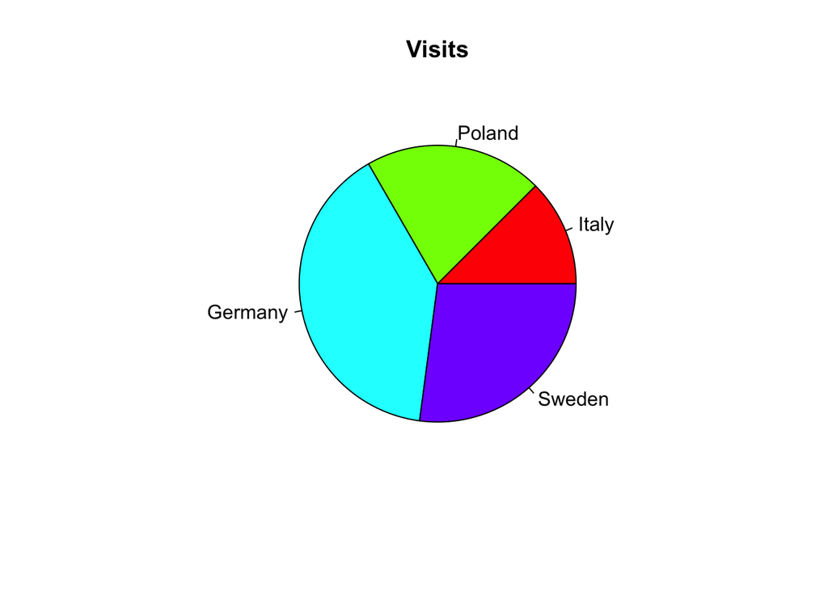

```r
pie(nodes$visits, labels=nodes$country, col = rainbow(length(nodes$visits)), main= "Visits")
```

# 2. Spatial Data

Adapted from

1. Weidmann (2022): Data Management for Social Scientists
2. Ward & Gleditsch (2008): Spatial Regression Models

Right now, R treats our data as a regular data frame, which is why we convert it into a spatial object. “coords=c(longitude, latitude)” requires us to specify the names of the columns where the spatial coordinates are stored.

Load sf package

```r
library(sf)
```

Enable dataset

```r
capital <- st_as_sf(nodes, coords = c("longitude_cap", "latitude_cap"), crs = 4326)
```

Check

```r
print(capital, n=4)
```

```
## Simple feature collection with 4 features and 4 fields
## Geometry type: POINT
## Dimension:     XY
## Bounding box:  xmin: 12.49637 ymin: 41.90278 xmax: 21.17822 ymax: 59.33459
## Geodetic CRS:  WGS 84
## # A tibble: 4 × 5
##   id        country visits CNTR_CODE            geometry
## * <chr>     <chr>    <dbl> <chr>             <POINT [°]>
## 1 Rome      Italy        6 IT        (12.49637 41.90278)
## 2 Warsaw    Poland      10 PL        (21.17823 52.19622)
## 3 Berlin    Germany     19 DE        (13.40495 52.52001)
## 4 Stockholm Sweden      13 SE        (18.06324 59.33459)
```

Load spatial data set for Europe (Source: Eurostat https://ec.europa.eu/eurostat/web/gisco/)

```r
europe <- st_read(file.path("NUTS_RG_60M_2021_4326"), crs=4326)
```

Plot spatial data set and add coordinates of capitals

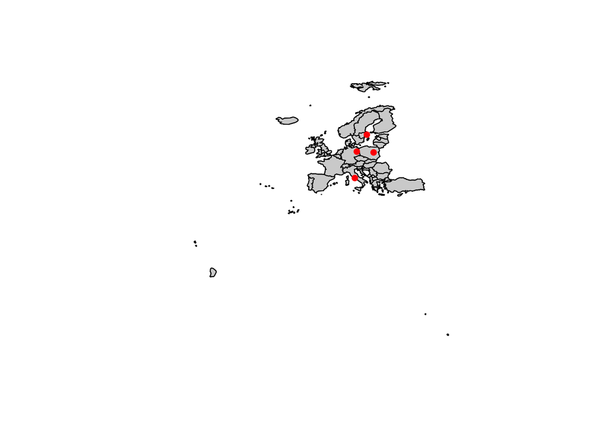

```r
plot(st_geometry(europe), col="lightgrey")
plot(st_geometry(capital), pch=16, col = "red", add=T)
```

Too large: subset only the countries we are interested in: DE, IT, SE, PL

```r
better <- europe[europe$CNTR_CODE=="DE" | europe$CNTR_CODE=="IT" |
                 europe$CNTR_CODE=="PL"| europe$CNTR_CODE=="SE",]
```

Plot again

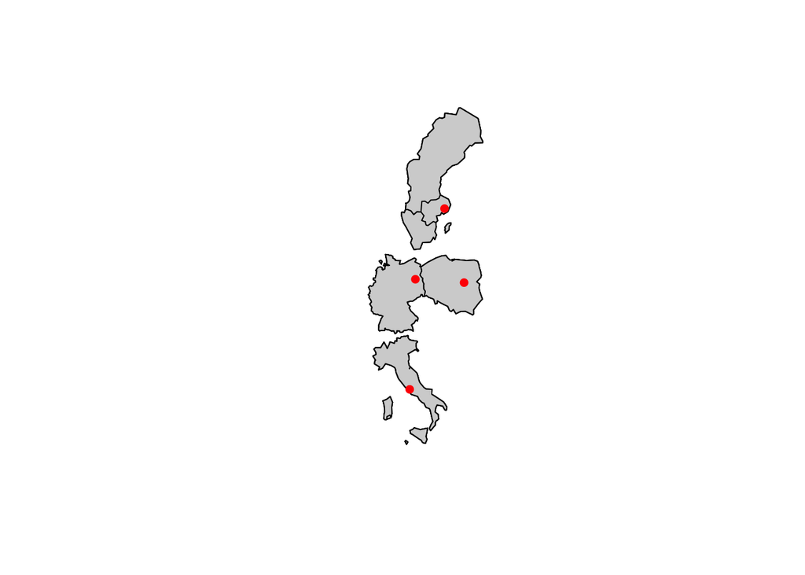

```r
plot(st_geometry(better), col="lightgrey")
plot(st_geometry(capital), pch=16, col = "red", add=T)
```

Now we want to color countries by number of visits. We therefore merge our data set with a data set which includes the information on the number of visits.

```r
better<- merge(better, nodes[,c("visits", "CNTR_CODE")], by = "CNTR_CODE", all = TRUE)
```

How many features are in each category or level?

```r
summary(better$visits)
```

```
##    Min. 1st Qu.  Median    Mean 3rd Qu.    Max.
##    6.00   10.00   19.00   15.09   19.00   19.00
```

Convert to factor

```r
better$visits <- as.factor(better$visits)
class(better$visits)
```

```
## [1] "factor"
```

Count the number of unique values or levels

```r
length(levels(better$visits))
```

```
## [1] 4
```

Create a color palette of 4 colors - one for each factor level

```r
road_palette <- c("grey80", "grey60", "grey40", "grey20" )
road_palette
```

```
## [1] "grey80" "grey60" "grey40" "grey20"
```

Create a vector of colors - one for each feature in the vector object according to its attribute value

```r
all_road_colors <- c("grey80", "grey60", "grey40", "grey20")[better$visits]
head(all_road_colors)
```

```
## [1] "grey20" "grey20" "grey20" "grey20" "grey20" "grey20"
```

Plot the lines data, apply a different color to each factor level. Then add the coordinates of the capitals. When adding the legend, x=“right” specifies the location of the legend. cex is the font size. After “fill=” we name the color palette we used to fill our objects with.

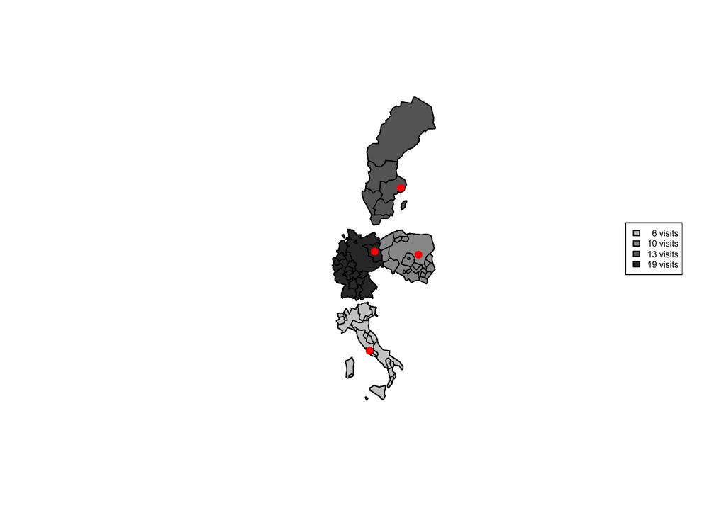

```r
plot(st_geometry(better), col= all_road_colors)
plot(st_geometry(capital), pch=16, col = "red", add=T)
legend(x = "right", c("  6 visits", "10 visits", "13 visits", "19 visits" ), cex = .5, fill = road_palette)
```

# 3. Network Data

Adapted from: Ognyanova (2016): https://kateto.net/wp-content/uploads/2016/01/NetSciX_2016_Workshop.pdf

Load package

```r
library(igraph)
```

Enable data set

```r
net <- graph_from_data_frame(d=links, vertices=nodes, directed=T)
```

# Plot network

edge.arrow.size=.4: size of arrow

vertex.color=“lightgrey”: node color

vertex.label=V(net)$id: specifies label of node

vertex.label.font=2: font type for the label (1: Times new Roman, 2: bold, 3: italic+, 4: italic+bold)

vertex.label.color=“black”: color of label

vertex.label.cex=.7: size of label within node

edge.color=“gray85”: edge color

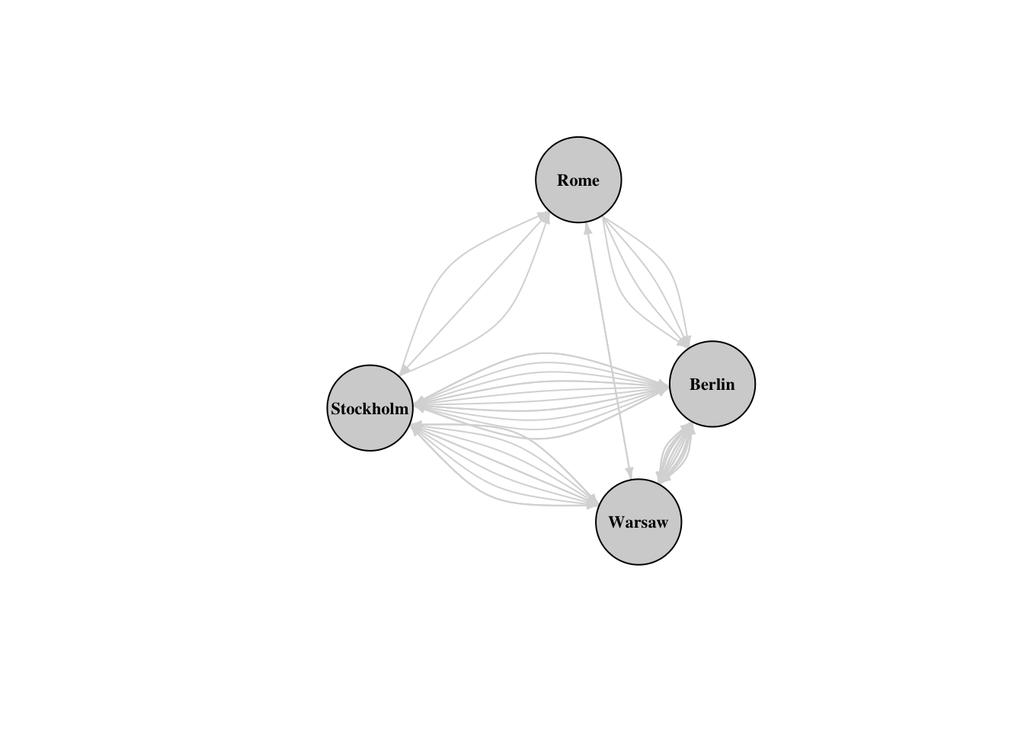

```r
plot(net, edge.arrow.size=.4, vertex.color="lightgrey", vertex.label=V(net)$id,
     vertex.label.font=2, vertex.label.color="black", vertex.size=50,
     vertex.label.cex=.7, edge.color="gray85")
```

Set node (/vertix) size based on number of visits

```r
V(net)$size <- V(net)$visits*3
```

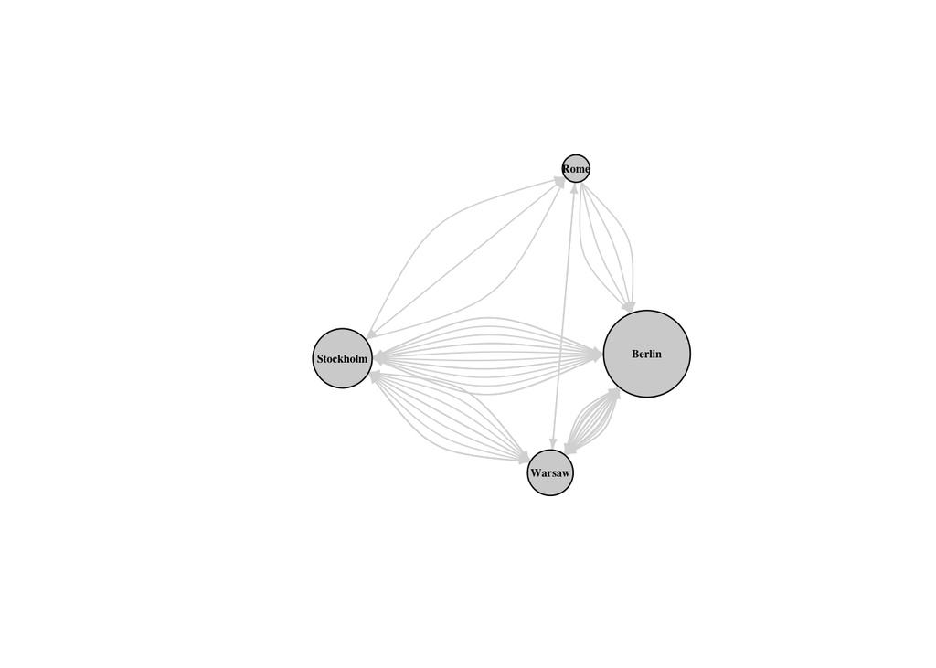

```r
plot(net, edge.arrow.size=.4, vertex.color="lightgrey", vertex.label=V(net)$id,
     vertex.label.font=2, vertex.label.color="black",
     vertex.label.cex=.5, edge.color="gray85")
```

## BONUS:

Color by long distance (>1,000 km)

```r
colrs <- E(net)$color <- ifelse( E(net)$dummy == "1", "tomato", "gold")
```

Plot and add legend

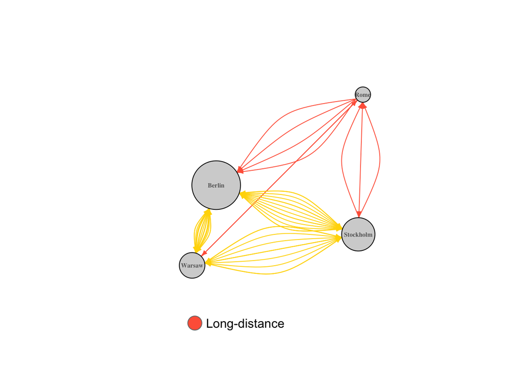

```r
plot(net, edge.arrow.size=.4, vertex.color="lightgrey", vertex.label=V(net)$id,
     vertex.label.font=2, vertex.label.color="gray40",
     vertex.label.cex=.5)
legend(x=-1.1, y=-1.5, c("Long-distance"), pch=21,
       col="#777777", pt.bg=colrs, pt.cex=2.5, bty="n", ncol=1)
```